# Part Two: Data Analysis

Henry Siegler and Michael Knauss

```r
library(tidyverse)
library(here)
library(modelr)
```

## The Data

```r
oscars <- read_csv(here("Oscars-demographics-DFE.csv"))
```

## Warm-Ups

**1. Which movie(s) won the most unique “Big 5” awards?**

```r
oscars %>%
  distinct(movie, award) %>%
  group_by(movie) %>%
  count(sort = TRUE) %>%
  filter(n == 3) %>%
  pull(movie)
```

```
##  [1] "A Streetcar Named Desire"    "Cabaret"
##  [3] "From Here to Eternity"       "Going My Way"
##  [5] "Gone with the Wind"          "It Happened One Night"
##  [7] "Kramer vs. Kramer"           "Million Dollar Baby"
##  [9] "Mrs. Miniver"                "Network"
## [11] "On the Waterfront"           "Terms of Endearment"
## [13] "The Best Years of Our Lives" "West Side Story"
```

All the above movies won 3 unique “Big 5”awards.

**2. Of all the actresses who have won the Best Actress award, what is the most common first name?**

```r
name <- oscars %>%
  distinct(person, .keep_all = TRUE) %>%
  filter(award == "Best Actress") %>%
  pull(person) %>%
  word(1) %>%
  table() %>%
  sort(decreasing = TRUE)

head(name)
```

```
## .
##    Helen     Jane Jennifer  Jessica     Joan    Julie
##        3        2        2        2        2        2
```

The most common first name is “Helen”, with 3 occurences.

**3. What US State, or non-US country, has produced the most Oscar Winners (for the awards in the dataset)?**

```r
oscars$birthplace <- gsub("New York City",
                          'New York City, Ny',
                          oscars$birthplace)

state <- oscars %>%
  distinct(person, .keep_all = TRUE) %>%
  pull(birthplace) %>%
  word(-1) %>%
  table() %>%
  sort(decreasing = TRUE)

head(state)
```

```
## .
##      Ny England      Ca      Il      Mo      Nj
##      56      46      32      18      10      10
```

Out of all US states or non-US countries, New York has produced the most Oscar winners, with 56 winners.

## Age and Gender

```r
oscars$date_of_birth[85] <- "5-Oct-1972"
oscars$date_of_birth[55] <- "18-Aug-1936"

modeldata <- oscars %>%
  separate(
    date_of_birth,
    into = c("day", "month", "year"),
    sep = "-") %>%
  mutate(
    day = as.numeric(day),
    year = as.numeric(year),
    year = case_when(year < 100 ~ 1900 + year,
                     TRUE ~ year),
    age = year_of_award - year,
    male = case_when(
      award == "Best Actress" |
      award == "Best Supporting Actress" ~ 0,
      award == "Best Actor" |
      award == "Best Supporting Actor" ~ 1,
      TRUE ~ 99)) %>%
  filter(male != 99)
```

```r
modeldata <- modeldata %>%
  #create a year of award variable where the first year of the awards is 0
  mutate(year_award_0 = year_of_award - min(modeldata$year_of_award))


model <- lm(age ~ year_award_0 + male, data = modeldata)

summary(model)
```

```
##
## Call:
## lm(formula = age ~ year_award_0 + male, data = modeldata)
##
## Residuals:
##     Min      1Q  Median      3Q     Max
## -27.427  -8.230  -3.056   6.104  41.787
##
## Coefficients:
##              Estimate Std. Error t value Pr(>|t|)
## (Intercept)  35.94345    1.53386  23.433  < 2e-16 ***
## year_award_0  0.05359    0.02745   1.952   0.0517 .
## male          9.54464    1.30950   7.289 2.13e-12 ***
## ---
## Signif. codes:  0 '***' 0.001 '**' 0.01 '*' 0.05 '.' 0.1 ' ' 1
##
## Residual standard error: 12.24 on 347 degrees of freedom
## Multiple R-squared:  0.1403, Adjusted R-squared:  0.1353
## F-statistic: 28.31 on 2 and 347 DF,  p-value: 4.098e-12
```

A linear model was created to predict the age of the Oscars winner using the year they won and their gender, using a binary variable with 1 indicating male and 0 indicating female. The model predicts how the age of the average winner has changed over time as well as if male and female groups win awards at different ages.

## Bootstrapping

```r
notwhite <- oscars %>%
  mutate(
    ethnicity = case_when(
      race_ethnicity != "White" ~ 1,
      TRUE ~ 0
    )) %>%
  select(ethnicity)

set.seed(37)

boot <- bootstrap(notwhite, 1000)
boot <- mutate(boot, prop = map_dbl(strap, ~mean(data.frame(.x)$ethnicity)))

#Confidence Interval
lower = quantile(boot$prop, 0.025)
upper = quantile(boot$prop, 0.975)


p <- boot %>%
  ggplot() +
  geom_density(aes(x = prop, y = ..density..), fill = "grey")

mapdata <- ggplot_build(p)$data[[1]]

lower
```

```
##      2.5%
## 0.0430839
```

```r
upper
```

```
##      97.5%
## 0.09297052
```

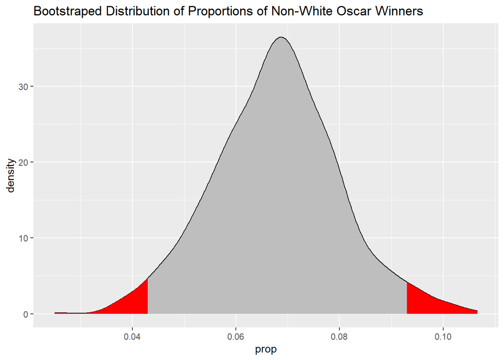

```r
p <-  p +
  geom_area(aes(x=x, y=y), data = subset(mapdata, x < lower), fill = "red") +
  geom_area(aes(x=x, y=y), data = subset(mapdata, x > upper), fill = "red") +
  ggtitle("Bootstraped Distribution of Proportions of Non-White Oscar Winners")

p
```

We are 95% confident that the true proportion of non-white oscars big 5 award winners is between 4.3% and 9.29%. The rejection regions for a hypothesis test for this proportion is shaded on the graph.